# Reproducible Research: Peer Assessment 1 - Aryaman Pande

## Loading and preprocessing the data

```r
setwd("C:/Users/arya/Desktop/coursera/R_pro/Rstudio/reproducible/week2")
data<-read.csv("activity.csv")
library(ggplot2)
summary(data)
```

```
##      steps            date              interval
##  Min.   :  0.00   Length:17568       Min.   :   0.0
##  1st Qu.:  0.00   Class :character   1st Qu.: 588.8
##  Median :  0.00   Mode  :character   Median :1177.5
##  Mean   : 37.38                      Mean   :1177.5
##  3rd Qu.: 12.00                      3rd Qu.:1766.2
##  Max.   :806.00                      Max.   :2355.0
##  NA's   :2304
```

```r
head(data)
```

```
##   steps       date interval
## 1    NA 2012-10-01        0
## 2    NA 2012-10-01        5
## 3    NA 2012-10-01       10
## 4    NA 2012-10-01       15
## 5    NA 2012-10-01       20
## 6    NA 2012-10-01       25
```

## What is mean total number of steps taken per day?

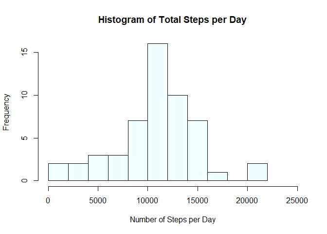

```r
stepsPerDay<- aggregate(data$steps, list(data$date), FUN=sum)
hist(stepsPerDay$x,breaks=8,xlab = "Number of Steps per Day",col = "azure",xlim = c(0,25000),main="Histogram of Total Steps per Day")
```

#### Mean total number of steps

```r
m <- mean(stepsPerDay$x, na.rm=TRUE)
m
```

```
## [1] 10766.19
```

#### Median total number of steps

```r
median(stepsPerDay$x, na.rm=TRUE)
```

```
## [1] 10765
```

## What is the average daily activity pattern?

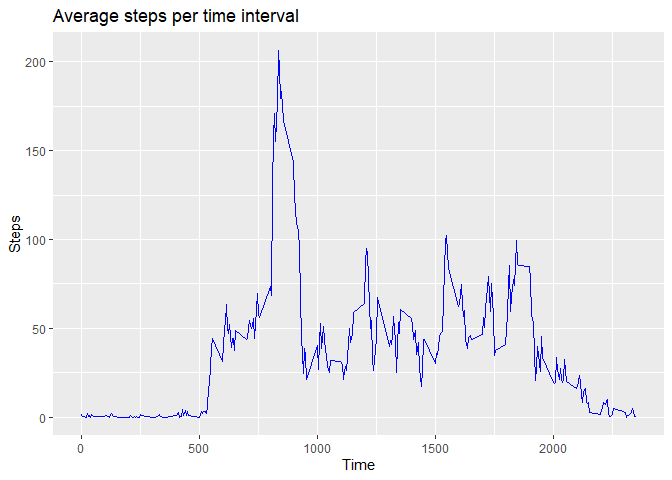

```r
stepsPerTime <- aggregate(steps~interval,data=data,FUN=mean,na.action=na.omit)
h <- ggplot(stepsPerTime, aes(interval, steps))
h+geom_line(col="blue")+ggtitle("Average steps per time interval")+xlab("Time")+ylab("Steps")
```

#### 5-minute interval (on average across all the days) with the max steps

```r
stepsPerTime[which.max(stepsPerTime$steps), ]$interval
```

```
## [1] 835
```

## Imputing missing values

#### Total number of missing values

```r
na = is.na(data$steps)
sum(na)
```

```
## [1] 2304
```

#### Devise a strategy for filling in all of the missing values in the dataset.

```r
data$steps[is.na(data$steps)]<-round(m/10000)
```

#### New dataset that is equal to the original dataset but with the missing data filled in

```r
dataFull <- data.frame(steps=data$steps, interval=data$interval, date=data$date)
head(dataFull)
```

```
##   steps interval       date
## 1     1        0 2012-10-01
## 2     1        5 2012-10-01
## 3     1       10 2012-10-01
## 4     1       15 2012-10-01
## 5     1       20 2012-10-01
## 6     1       25 2012-10-01
```

```r
stepsPerDayFull <- aggregate(dataFull$steps, list(dataFull$date), FUN=sum)
head(stepsPerDayFull)
```

```
##      Group.1     x
## 1 2012-10-01   288
## 2 2012-10-02   126
## 3 2012-10-03 11352
## 4 2012-10-04 12116
## 5 2012-10-05 13294
## 6 2012-10-06 15420
```

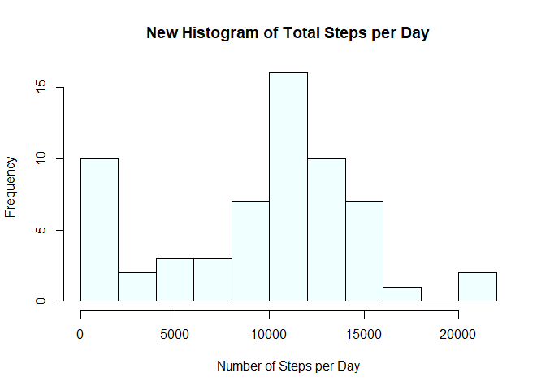

```r
# draw the histogram
hist(stepsPerDayFull$x,breaks=8,xlab = "Number of Steps per Day",col = "azure",main="New Histogram of Total Steps per Day")
```

```r
# The values do differ from first part since we have filled in the man/10000 amt. of steps in each interval.
# This has led to an increase in total number of steps per day
```

## Are there differences in activity patterns between weekdays and weekends?

#### Create a new factor variable in the dataset with two levels - “weekday” and “weekend” indicating whether a given date is a weekday or weekend day.

```r
dataFull$RealDate <- as.Date(dataFull$date, format = "%Y-%m-%d")

dataFull$weekday <- weekdays(dataFull$RealDate)
# create a new variable indicating weekday or weekend
dataFull$DayType <- ifelse(dataFull$weekday=='Saturday' | dataFull$weekday=='Sunday', 'weekend','weekday')
# see first 10 values
head(dataFull, n=10)
```

```
##    steps interval       date   RealDate weekday DayType
## 1      1        0 2012-10-01 2012-10-01  Monday weekday
## 2      1        5 2012-10-01 2012-10-01  Monday weekday
## 3      1       10 2012-10-01 2012-10-01  Monday weekday
## 4      1       15 2012-10-01 2012-10-01  Monday weekday
## 5      1       20 2012-10-01 2012-10-01  Monday weekday
## 6      1       25 2012-10-01 2012-10-01  Monday weekday
## 7      1       30 2012-10-01 2012-10-01  Monday weekday
## 8      1       35 2012-10-01 2012-10-01  Monday weekday
## 9      1       40 2012-10-01 2012-10-01  Monday weekday
## 10     1       45 2012-10-01 2012-10-01  Monday weekday
```

#### Make a panel plot containing a time series plot (i.e. type = “l”) of the 5-minute interval (x-axis) and the average number of steps taken, averaged across all weekday days or weekend days (y-axis).

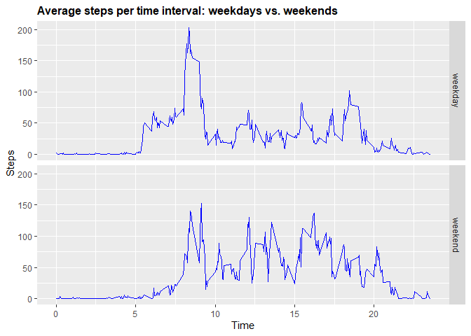

```r
a <- aggregate(steps~interval+DayType,data=dataFull,FUN=mean,na.action=na.omit)
a$time <- stepsPerTime$interval/100
j <- ggplot(a, aes(time, steps))
j+geom_line(col="blue")+ggtitle("Average steps per time interval: weekdays vs. weekends")+xlab("Time")+ylab("Steps")+theme(plot.title = element_text(face="bold", size=12))+facet_grid(DayType ~ .)
```